# The Synthetic Confounder

Recovering a time-varying latent confounder from pre-treatment outcomes, the failures it repairs, and a sensitivity analysis for what remains

Chad Hazlett and Borna Bateni  
UCLA Statistics & Data Science; Political Science

## Interventions and panels

- We often want to learn the effect of a treatment taken, or a policy adopted, by some units rather than others, at some point in time.
- Panels (longitudinal data) seem promising because repeated pre-treatment outcomes let units serve as their own controls, and carry information about confounders we never observe.
- Two families exploit this: One uses **differencing** to target time-invariant confounding (e.g. DiD, FE); the other **conditions on prior outcomes** (e.g. LDV, synthetic control, balancing on $Y_{pre}$). Others add instruments (Arellano-Bond) or combine the families (FE+LDV).

**Today:**

- A walk through why, under conditions we usually cannot rule out, **all existing methods fail**.
- A proposal to **recover the confounder’s impact path rather than proxy for it with $Y_{pre}$**.
- To foreshadow: Our proposal will contrast with DiD but is close to LDV/synth in theory and practice, while improving on their ability to handle (time-invariant *and* time-varying) confounding by capturing a rank-one confounder.

## Disclaimer

1. This is a work in progress, and my first time talking about it.
2. We are still learning as we go, including uncovering existing options that sometimes have strengths or weaknesses we didn’t recognize.
3. I’m hoping your questions and insights help push us along, so thank you. I may take your question home with me rather than answering it.

## Setup and three things we can’t rule out

[figure not shown]

- $Y$ observed as $Y_1,\ldots,Y_T,\ Y_{\text{post}}$.
- Treatment $D$ given to some units after $T$.
- Under staggered adoption, repeat wave-wise with appropriate group…handles any concern the “new DiD” literature raises (Callaway & Sant’Anna; Sun & Abraham; de Chaisemartin & D’Haultfœuille; Goodman-Bacon).

**Three things to worry might exist:**

1. **A latent (possibly) time-varying confounder.** $U_i$ is a fixed trait but its impact on each $Y$ (and $D$) depends on $f_t$ (including $f_D$, $f_{\text{post}}$).
2. **Feedback from outcomes into treatment.** Treatment hears the recent outcome(s), $Y_T \to D$, shocks included.
3. **Autocausation.** Past outcomes cause later ones, up to $\nu$ periods back (the $\gamma$-labelled chain). We will use $\nu=1$ throughout but that could be changed.

## Is it hard to rule these out in practice?

| study | method | time-varying confounder | feedback | autocausation |
| --- | --- | --- | --- | --- |
| Abadie, Diamond & Hainmueller 2010 (Prop 99) | synth | anti-smoking sentiment, rising through the 1980s; willingness to use tax policy | policy could be encouraged by smoking levels | habit, supply |
| Card & Krueger 1994 (minimum wage on employment) | DiD | economic trends and cycles, political sentiment | employment as influence on wage laws | employment begets a level of employment |
| Ashenfelter 1978; Ashenfelter & Card 1985 (training) | DiD / LDV | time-varying causes other than employment itself (education, economic conditions) | lost earnings $\rightarrow$ training | earnings largely persist or mean revert |
| Acemoglu, Naidu, Restrepo & Robinson 2019 (democracy $\rightarrow$ GDPpc) | FE+LDV / AB | state capacity | democratization follows GDP dips (authors note) | persistence of GDPpc (authors note) |
| Nunn & Qian 2014 (food aid, conflict) | IV+FE | avoided if instrument (lagged wheat production) is good | wheat production (t-1) $\rightarrow$ food aid (t) | conflict persists |
| Xu, 2021 (“Golden Shield”; program $\rightarrow$ county security spending) | synth, LDV, TWFE | county capacity (needed to get program), demand for security spending | spending collapse $\rightarrow$ adoption | spending/budgets largely persist |

**My supposition**:

- Time-varying confounding: typically hard to rule out.
- Auto-causation: typically hard to rule out.
- Feedback is sometimes explicit, sometimes a risk, and occasionally ruled out by treatment assignment information.

## A parametric crutch

We proceed as if we want to know parameters from the model:
$$\begin{aligned}
Y_{it}(0) &= \textstyle\sum_{t-s \le \nu} \gamma_{s,t}\, Y_{is} + f_t\,U_i + \varepsilon_{it} \\
D_i &= \mathbf{1}\{\textstyle\sum \gamma_{s,D}\, Y_{is} + f_D\,U_i + \varepsilon_{iD} > c\} \\
\end{aligned}$$
Producing the final-period equation:
$$Y_{i,\text{post}} = \textstyle\sum \gamma_{s,\text{post}}\, Y_{is} + \tau D_i + f_{\text{post}}\,U_i + \varepsilon_{i,\text{post}}$$

where we will call the $\varepsilon_{i,t}$ **shocks**.

**Assumes:**

- linear factor model $f_t U_i$; optionally we impose dim(U)=dim(f)=1 below.
- **vanishing lag** after $\nu$ (key identifying assumption)
- $\tau$ is constant…or not but the estimation will then give a weighted average.

## Simulation settings

- Following the same parametric model above, with $T = 8$ pre-periods, one post-period, $\tau = 1$; $U_i \sim N(0,1)$ and every shock $\varepsilon_{it},\varepsilon_{iD},\varepsilon_{i,\text{post}} \overset{iid}{\sim} N(0,1)$, mutually independent and independent of $U_i$.
- **Fixed across truths:** $\gamma_y = \gamma_{\text{post}} = 0.4$ (autocausation), $\gamma_D = 0.5$ (feedback), $f_D = 0.6$, 30% treated; a 10-period burn-in so the sample starts at steady state.
- **Random per draw:** $U, \varepsilon$. 60 draws per cell.
- **What varies** across settings: the *shape* of the impact path $f_t$.
- **Calibration**: scale $f$ so that $U$ explains **25% of $\operatorname{Var}(Y_{pre})$**

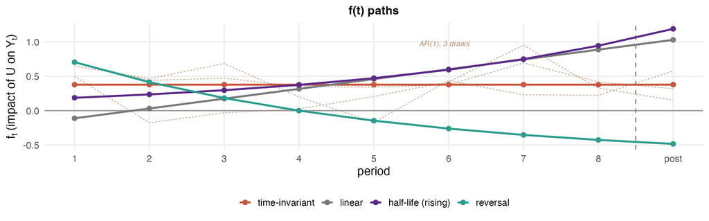

## The tour

**Differencing family**

- DiD (last pre-period)
- Two-way FE (TWFE)
- Arellano-Bond

**Conditioning family**

- Lagged DV
- Synthetic control
- Balancing on $Y_{pre}$

**Both at once**

- TWFE + lagged DV

## DiD’s feedback problem

- *Idea*: Use $Y_{\text{post}} - Y_T$, regressed on $D$. Time-invariant confounding removed.
- *Requires:* parallel trends, i.e. **nothing related to the trend (in $Y(0)$) is related to $D$.** Hard to support, but imagined to be plausible under time-invariant confounding.
- *Breaks* under time-varying confounding, but also absent confounding (of any kind) due to **feedback**. Why?

Suppose there is no confounder. The plain difference in means (DiM) is unbiased.

But a shock in $Y_T$ influences $D$, creating pre-treatment difference $\Delta_T = E[Y_T\mid D{=}1] - E[Y_T\mid D{=}0]$.

Now,

$$\text{DiD} \;=\; \text{DiM} - \Delta_T$$

so $\Delta_T$ is pure bias.

## Auto-causation adds a layer

DiD would be fine with autocausation alone, but together with feedback, $Y_T$ becomes a confounder of $D$ and $Y$.

The bias from omitting $Y_T$ is its *impact times imbalance*: $\gamma_{\text{post}} \Delta_T$.

*Conditioning* on $Y_T$ removes exactly that, but subtracting $1 \times Y_T$ leaves bias:

$$\gamma_{\text{post}}\Delta_T - \Delta_T \;=\; (\gamma_{\text{post}}-1)\,\Delta_T$$

So you subtracted off the wrong amount unless $\gamma_{\text{post}}=1$.

Most famously, if $\gamma_{\text{post}} < 1$ ($Y$ is mean-reverting) selection on a transitory shock produces the **Ashenfelter dip**.

## Combining this with confounding

If $U$ affects $D$ we have imbalance on it: $E[U \mid D{=}1] \neq E[U \mid D{=}0]$

$f_t$ multiplies this, contributing to difference between arms on $Y(0)$, $\Delta_t = E[Y_t(0)\mid D{=}1] - E[Y_t(0)\mid D{=}0]$

**DiD bias** is $\Delta_{\text{post}} - \Delta_T$, read off the last step minus the one before.

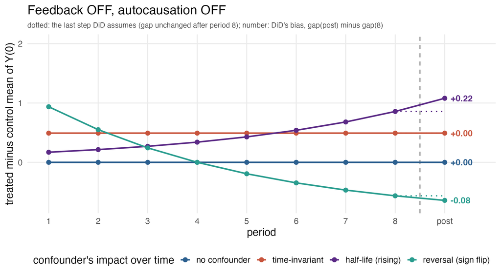

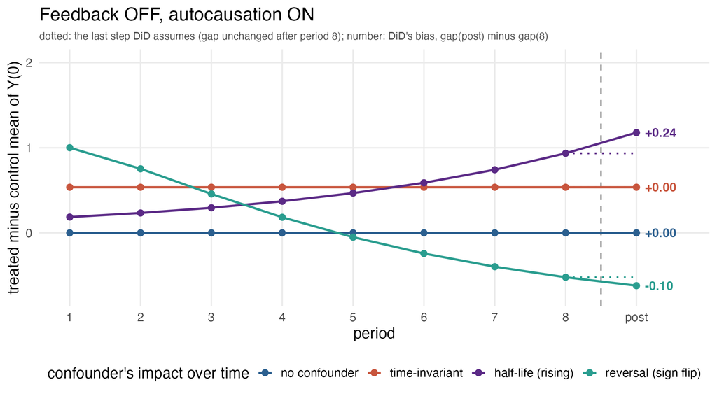

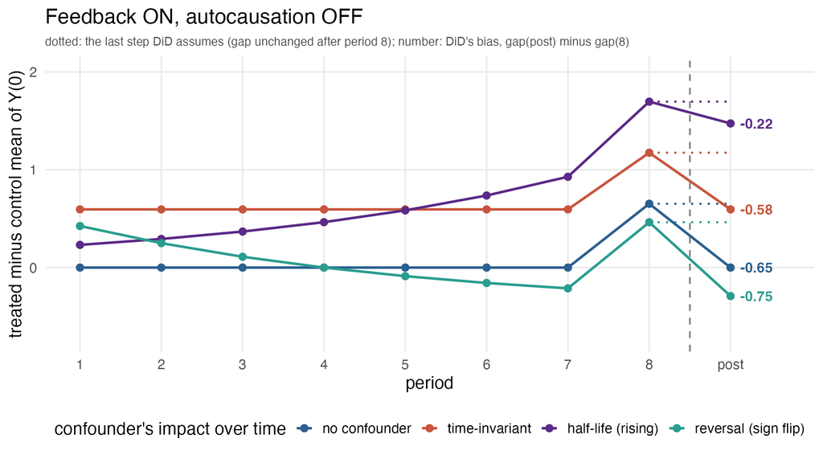

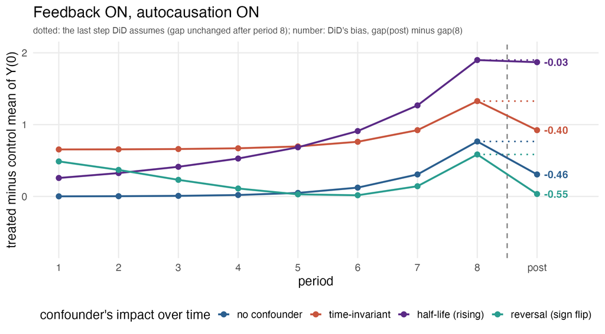

**Neither switched on.** No confounder: nothing. Time-invariant: a constant gap, DiD exactly right. A *moving* impact bends the gap, and the last step is DiD’s bias. The ordinary parallel-trends failure.

**Autocausation only.** Nothing changes: a flat $f$ is still flat at steady state, the moving shapes still bend. Autocausation alone does not bend trends.

**Feedback only.** With no confounder the gap is *exactly zero* through period 7, spikes at period 8 (selection on $Y_T$), and reverts at post. All bad!

**Both.** Same problems; DiD still won’t work.

## Two-way fixed effects and Arellano-Bond

- *TWFE:* unit and period fixed effects over all $T+1$ periods.
  - Removes time-invariant confounding.
  - It differences from an *average* of the pre-periods rather than from $Y_T$ alone, so it inherits a piece of the feedback problem suffered by DiD.
- *Arellano-Bond:* first-difference the outcome to remove the unit effect, then instrument the (now endogenous) lagged difference $\Delta Y_{t-1}$ with deeper lags $Y_{t-2}, Y_{t-3}, \ldots$, which are valid instruments if shocks are serially uncorrelated.
  - Fixes Nickell bias, but **leaves the feedback problem untouched**: once differenced, $D$ is correlated with the selected-on shock in $Y_T$, and $D$ has no lags of its own to instrument with.
- Either is okay when no time-varying confounding and no feedback, same as DiD.

## The conditioning family

Lagged DV, synthetic control, balancing on $Y_{pre}$

- **LDV:** regress $Y_{\text{post}}$ on $D$ and the history, $Y_{i,\text{post}} = \alpha + \tau D_i + \sum_t \beta_t Y_{it} + e_i$; $\hat\tau$ is the coefficient on $D$.
- **Balancing on $Y_{pre}$:** reweight controls so their pre-period means *exactly* match the treated units’ (a hard constraint; infeasible if the treated mean lies outside the control hull).
- **Synthetic control:** the same idea, but where exact pre-treatment balance is not possible, minimize and report the imbalance.
- We will just combine these into **“balance on $Y_{pre}$ / synth”** where weights are feasible.

**Handles feedback and autocausation:** conditioning on $Y_T$ is exactly what selection used.

**But $Y_{pre}$ doesn’t catch all confounding:**

- Consider $U_i = b'Y_{pre,i} + r_i$: modeling $Y_{pre}$ can handle *only* the $b'Y_{pre}$ part
- The $r_i$ could be noise, non-linearity, or missing information.

**Key failures of $Y_{pre}$ conditioning:**

- If $Y_{pre}$ is a noisy proxy for $U$, then $\lVert r \rVert > 0$ and conditioning on $Y_{pre}$ falls short $\rightarrow$ **errors-in-variables** (EIV) bias.
- Or if $E[U \mid Y_{pre}] \neq U$, it means $Y_{pre}$ isn’t handling $U$, a “sleeping giant” identification problem.

## TWFE + lagged DV: one from each family

Both parents’ machinery in one estimating equation, fitted by the within transform:

$$Y_{it} \;=\; \alpha_i \;+\; \delta_t \;+\; \gamma\,Y_{i,t-1} \;+\; \tau\,D_{it} \;+\; \varepsilon_{it}$$

$\alpha_i$ a unit effect, $\delta_t$ period effects, $\gamma$ the autoregressive coefficient (the coefficient on the unit’s own previous outcome), $D_{it}$ the treatment indicator.

- **From FE it inherits the removal of time-invariant confounding.** A unit constant absorbs a confounder whose impact does not move — *exactly*, with no errors-in-variables to pay. That is what LDV cannot do.
- **Like LDV, conditioning on $Y_{i,t-1}$ handles the feedback** that makes $Y_T$ a confounder of $D$ and $Y_{\text{post}}$ — *almost*. Demeaning damages the very regressor doing that work (Nickell bias, vanishing at $O(1/T)$.
- **Under time-invariant confounding *with* feedback and enough $T$ it still beats either parent**
- **Under *time-varying* confounding it fails**: FEs aren’t enough, plus the damaged lag under-controls.

## Bias by method and truth ($n = 2000$)

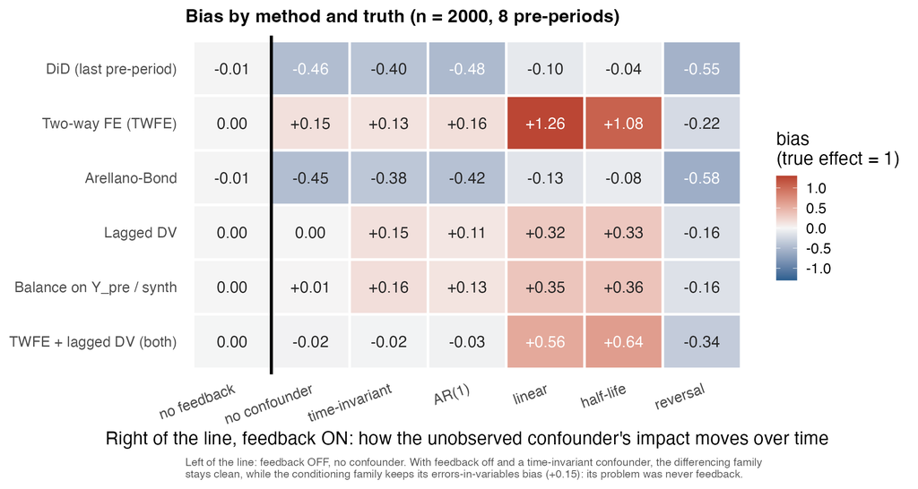

## The differencing family on the map

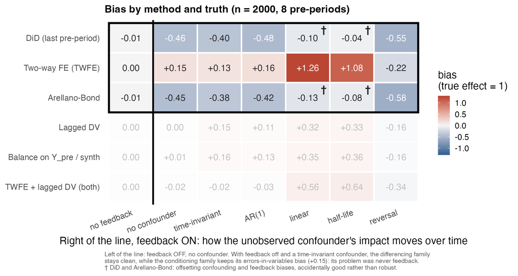

† DiD (and Arellano-Bond) suffer *offsetting* confounding and feedback biases here, which makes them look accidentally good, not robust. See extra slides.

## The conditioning family on the map

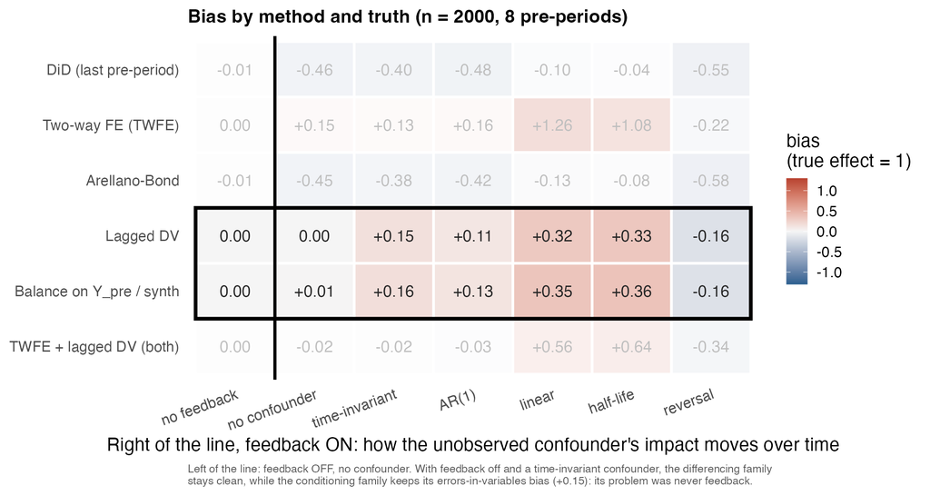

## The hybrid: both at once

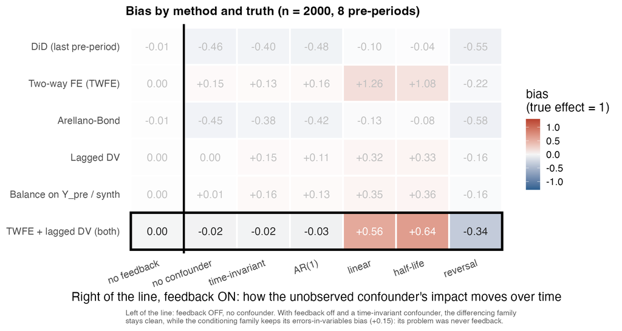

# Synthconf

## The regression we want

We are willing to work from the model:
$$Y_{i,\text{post}} = \textstyle\sum\gamma_{s,\text{post}}Y_{is} + \tau D_i + f_{\text{post}}U_i + \varepsilon_{i,\text{post}}$$

- The “long regression”: if $U_i$ were observed we would regress $Y_{\text{post}}$ on $D$, $U$, and $Y_{pre}$, and $\tau$ would be the coefficient on $D$.<sup>1</sup>
- That regression would use the full covariance matrix $\operatorname{Var}(Y_{i1},\ldots,Y_{iT},\ D_i,\ Y_{i,\text{post}},\ U_i)= \operatorname{Var}(Z_i,U_i)$.
- Really we need only its inverse, $\operatorname{Var}^{-1}(Z_i,U_i)$, which we call $P$, the precision matrix.

**Fact (regression coefficients from a precision matrix).** By example,

$$\tau \;=\; -\,\frac{P[\text{post}, D]}{P[\text{post},\text{post}]}
\qquad\text{and, }\qquad
\text{coef of } Y_s \text{ on regressing } Y_t \;=\; -\,\frac{P[t, s]}{P[t,t]} .$$

[^1]: Its coefficient averages heterogeneous effects differently than the ATE, though with a single treated unit it is exactly the ATT from g-computation.

## $P$ cannot be built without $U$’s covariances

- We observe $\Sigma_{\text{obs}}= \operatorname{Var}(Y_{i1},\ldots,Y_{iT}, D_i, Y_{i,\text{post}}) = \operatorname{Var}(Z_i)$; we are missing the $\operatorname{Cov}(Z_i,U_i)$ row and column.
- If we use $\Sigma_{\text{obs}}^{-1}$ to compute $\hat\tau$ missing $U$, that is just **LDV**.
- But we want $P$, or rather the relevant block of it, $\tilde{P} = P_{[-U,-U]}$. Write the difference as
  $$\tilde{P} \;=\; \Sigma_{\text{obs}}^{-1} \;+\; L$$
- The **Schur complement** tells us $L = P_{ZU}\,P_{UU}^{-1}\,P_{UZ}$, where $P_{ZU}$ pairs $Z_i$ with $U_i$ and $P_{UU}$ is $U$’s own block.
- So $L$ is **positive semidefinite** ($P_{UU} \succ 0$) with $\operatorname{rank}(L) = \dim(U)$ ($P_{ZU}$ has one column per confounder). True for any number of latent factors.

We need to **choose an $L$**, then add it to our observed precision so we get $\tilde{P}$, then read $\hat\tau$ off the result.

But what will tell us we have the right $L$?…

## Covariance implications of the true confounder

Staring at the DAG, you can see which $(Y_t, Y_s)$ pairs should be independent *conditionally on $U$*:

[figure not shown]

With $\nu = 1$, any pair more than one period apart has **no direct edge and no shared child** — so once $U$ is conditioned on, nothing connects them. These *vanishing lags* become the **zeros of the precision matrix**.

## Structure of $\tilde{P}$, and $L$

For $T = 4$, $\nu = 1$, the $Z$-block $\tilde{P}$ is
$$\small
\tilde{P} \;=\;
\begin{array}{c|cccccc}
& Y_1 & Y_2 & Y_3 & Y_4 & D & Y_{\text{post}}\\ \hline
Y_1 & \ast & -\tfrac{\gamma_{12}}{\sigma^2_2} & \color{gray}{0} & \color{gray}{0} & \color{gray}{0} & \color{gray}{0}\\
Y_2 & \cdot & \ast & -\tfrac{\gamma_{23}}{\sigma^2_3} & \color{gray}{0} & \color{gray}{0} & \color{gray}{0}\\
Y_3 & \cdot & \cdot & \ast & -\tfrac{\gamma_{34}}{\sigma^2_4} & \color{gray}{0} & \color{gray}{0}\\
Y_4 & \cdot & \cdot & \cdot & \ast & \ast & \ast\\
D & \cdot & \cdot & \cdot & \cdot & \ast & -\tfrac{\tau}{\sigma^2_{\text{post}}}\\
Y_{\text{post}} & \cdot & \cdot & \cdot & \cdot & \cdot & \tfrac{1}{\sigma^2_{\text{post}}}
\end{array}$$

Since $\tilde{P} = \Sigma_{\text{obs}}^{-1} + L$ holds **entry by entry**: where $\tilde{P}=0$, then $L = -\Sigma_{\text{obs}}^{-1}$, *read off the data*; off the zeros we choose $L$ via likelihood (next).

## Rank restrictions, penalties, identification, and optimization

We have tried many approaches to choosing $\tilde{P}$ but the current winner uses a two step approach.

(For concreteness, consider a case with T=8, $\nu=1$.)

- Each of 35 forced zeros is one equation
- If we worked with a rank-one L, we’d have 10 unknowns; ample over-identification.
- However a sharply rank-restricted optimization is highly multimodal and non-convex
- Instead we start with a convex variant that penalizes higher rank over a (partly) free $L$
  - Here that would have 55 unknowns: unidentified but for the penalty.
- We can use this to get in the right basin to later search for rank-1 solution.

## Step 1: Rank-penalized likelihood

- If $\varepsilon$ and $U$ are Gaussian so is $Z_i = (I-\Gamma^\top)^{-1}(fU_i + \varepsilon_i)$, and it’s estimated precision is $\Sigma_{obs}^{-1} = \tilde{P} - L$.
- Precision matrix is sufficient for the log-likelihood over observations: $\tfrac{n}{2}\big[\log\det (\tilde{P} - L) - \operatorname{tr}( (\tilde{P}-L)\,\hat\Sigma_{\text{obs}})\big]$ + const.
- Add penalty $\mu\operatorname{tr}(L)$ to encode a prior preference for low rank, so find:
  $$\min_{\tilde{P},L}\; -\log\det(\tilde{P}-L) + \operatorname{tr}\big((\tilde{P}-L)\hat\Sigma_{\text{obs}}\big) + \mu\operatorname{tr}(L),$$
  subject to $\tilde{P} = 0$ on the known zero pattern and $L \succeq 0$.
- One global optimum, no starts, about a tenth of a second. Never inverts the sample covariance. This is **synthconf-rp** (rank-penalised).
- If we stopped here, you could read $\hat\tau = -\hat{\tilde{P}}[D,\text{post}]\,/\,\hat{\tilde{P}}[\text{post},\text{post}]$

## Step 2: Impose rank restriction

- **synthconf-rp** is convenient but scary: $\hat{L}$ identified by the penalty.
- It shrinks toward $L = 0$, i.e. “no confounder”, the LDV answer. Nice when that is true, costly when it is not.
- A rank-one solution would avoid that and is (over-) identifiable, just hard to find.
- Hence, **synthconf-r1**:
  - We have $\hat L_{\text{rp}} \succeq 0$ from synthconf-rp
  - Take its leading eigenpair $(\lambda_1, v_1)$ and set $\ell_0 = \sqrt{\lambda_1}\,v_1$, so $\ell_0\ell_0^\top = \lambda_1 v_1v_1^\top$ — the **best rank-one approximation** to $\hat L_{\text{rp}}$;
  - refit $(\tilde{P}, \ell)$ by BFGS on the same (unpenalized) likelihood, starting from $\ell_0$.
- **Inference:** a delta-method standard error worked well in simulation, but did not match the bootstrap on the applications — so we report **bootstrap intervals** for now.

## No sleeping giants

There is a deeper identification threat, faced by all methods relying on $Y_{pre}$ to find $U$: **no sleeping giants**.

- synthconf detects confounding by watching entries that are supposed to be zero.
- Suppose the time-varying factor was $f_1 = \cdots = f_T = 0$, but with $f_D$ and $f_{\text{post}}$ not 0. … thus $f_t*U_i$ moves $D$ and $Y_{\text{post}}$ without leaving a fingerprint on the pre-period outcomes.
- Mechanically, such a factor leaves the footprint $\operatorname{Cov}(Z_i, U_i) = (0,\ldots,0,\ f_D,\ f_{\text{post}})$, so the only covariances it touches are $\operatorname{Var}(D)$, $\operatorname{Cov}(D, Y_{\text{post}})$, and $\operatorname{Var}(Y_{\text{post}})$. Those entries are pinned by the likelihood, but the likelihood is **silent on whether they come from $f_D f_{\text{post}}\operatorname{Var}(U)$ or from $\tau$**. The giant and the effect can’t be told apart.
- *Contrast:* a confounder that **did** touch the pre-periods perturbs something like $\operatorname{Cov}(Y_1, Y_5)$, a pair more than $\nu$ apart whose precision entry is **forced to zero**.
- Recall, conditioning family similarly blind to sleeping giants: if $Y_{\text{pre}}$ sees no trace of $U_i$ its span does not contain it.
- This is simply an unmeasured confounder, with neither conditioning nor the vanishing lag constraints can capture.

## Sensitivity analysis: pricing what we cannot see

The two main blind spots:

- **Sleeping giants** — a confounder acting on $D$ and $Y_{\text{post}}$ that leaves no earlier trace, so we don’t find it by watching for zero vanishing lags or in $\text{span}(Y_{\text{pre}})$.
- **Higher rank confounders** — what if $\dim(U) = \dim(f) > 1$?

Recall that $\hat\tau$ is the coefficient on $D$ in the implied regression of $Y_{\text{post}}$ on $\{Y_{pre}, D, \hat u\hat f\}$.

- **Omitted variable bias.** For some $w_{it}$ you wish you had included, its omission moves $\hat\tau$ through only two quantities: $R^2_{Y\sim w \mid D, Y_{\text{pre}}, \hat{U}}$ and $R^2_{D \sim w \mid Y_{\text{pre}}, \hat{U}}$.
- Report adjusted estimate for postulated values of $R^2_{Y\sim w \mid D, Y_{\text{pre}}, \hat{U}}$ and $R^2_{D \sim w \mid Y_{\text{pre}}, \hat{U}}$.
- E.g., the **robustness value**: how strong $w$ must be, on both channels at once, to drive $\hat\tau$ to zero.
- **Benchmark** against the recovered confounder itself: *“a second factor $k$ times as strong as the one we already removed”*.

## Synthconf simulation results

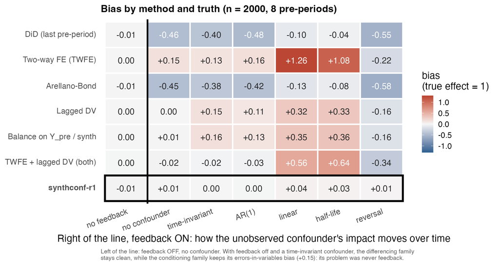

## Does it recover the impact path?

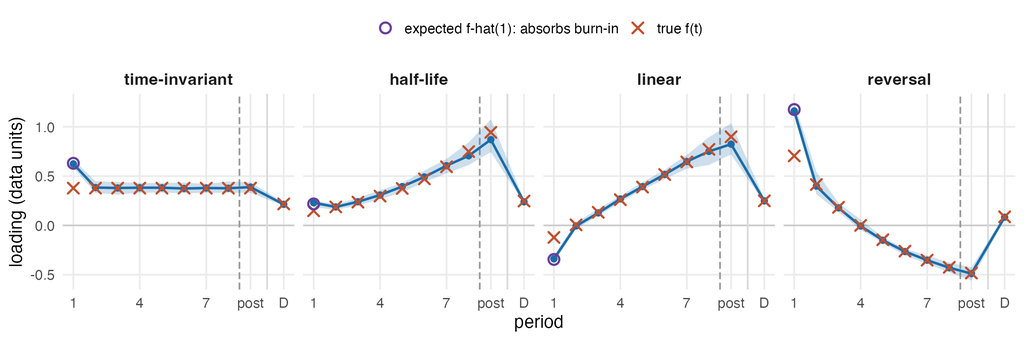

- Our hope is to estimates $f(t)$ rather than hoping $Y_{pre}$ proxies for it. It works!
- Blue is the median of 60 fits at $n = 2000$, band $10$–$90\%$; orange $\times$ is the truth.
- **Period 1 is not an error.** The model has no lag for $Y_1$, so $\hat f(1)$ must absorb the pre-sample accumulation — the open circle is that target, $g(1)$.

## Smaller samples

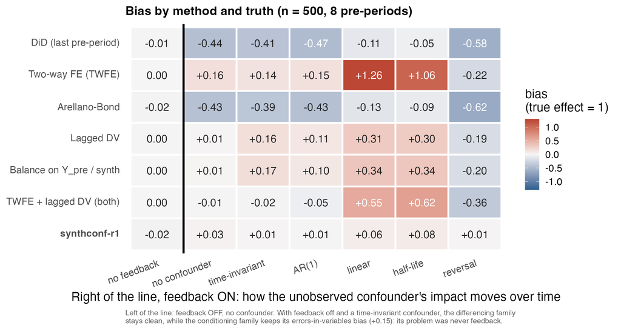

## Simulation RMSE

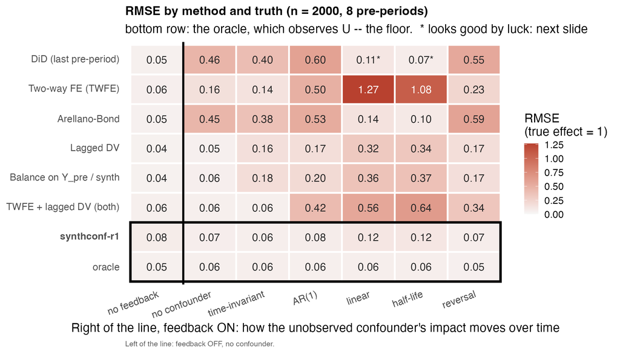

## California Proposition 99

- **Units:** 39 US states — California plus 38 donors that had no large-scale tobacco-control program of their own.
- **Treatment:** Prop 99, passed November 1988, in force January 1989: a 25¢-per-pack excise tax plus earmarked anti-smoking funding. **One treated unit, one wave.**
- **Outcome:** annual cigarette sales, packs per capita (levels).
- **Timing:** pre-period 1977–1988; post-period 1989 (and 1990).
- Why start here: this is **synthetic control’s home turf** — small $n$, a single treated unit, a long pre-history — and the canonical application (Abadie, Diamond & Hainmueller 2010).

## California Proposition 99 (I)

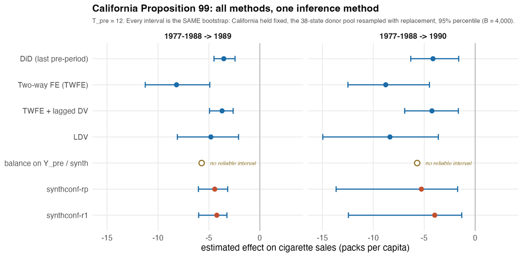

- Every interval is the same bootstrap: California held fixed, the 38 donors resampled, 95% percentile ($B=4{,}000$). Earlier versions mixed three, so widths were not comparable.
- With one treated unit this measures donor-pool variability only — conditional on California, silent about uncertainty in the treated unit, for *any* arm.
- No interval for balance/synth because a fifth of draws fail.

## California Proposition 99 (II)

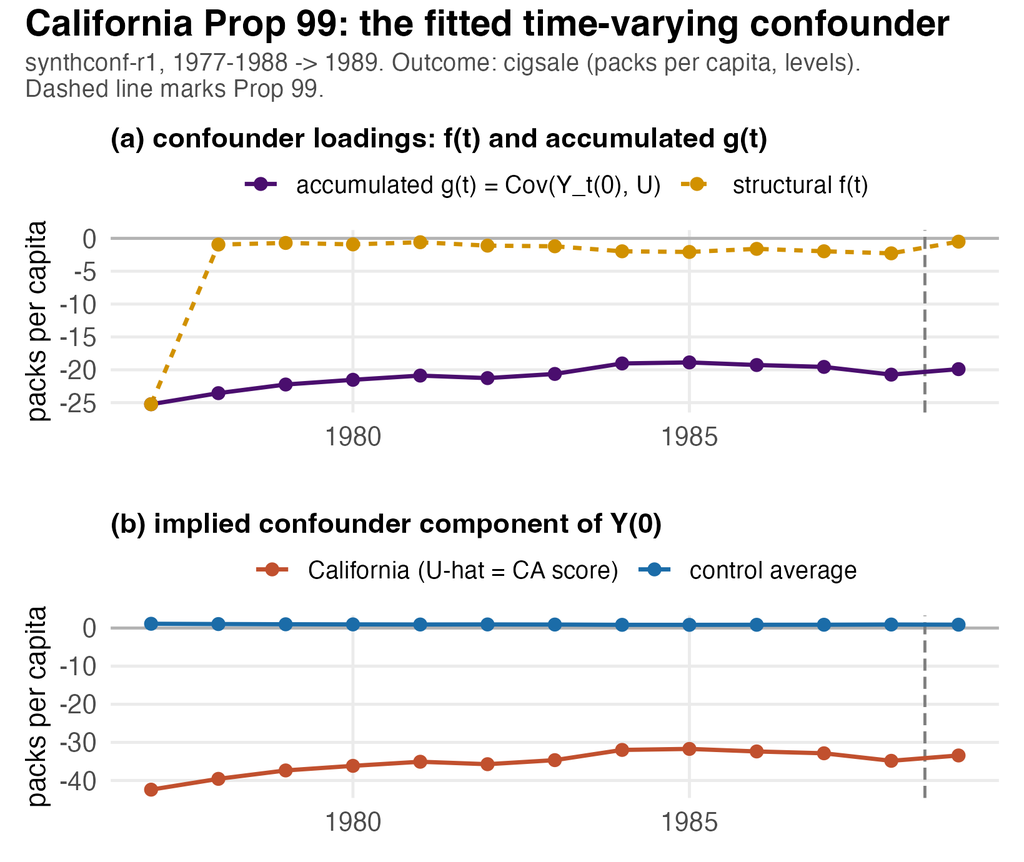

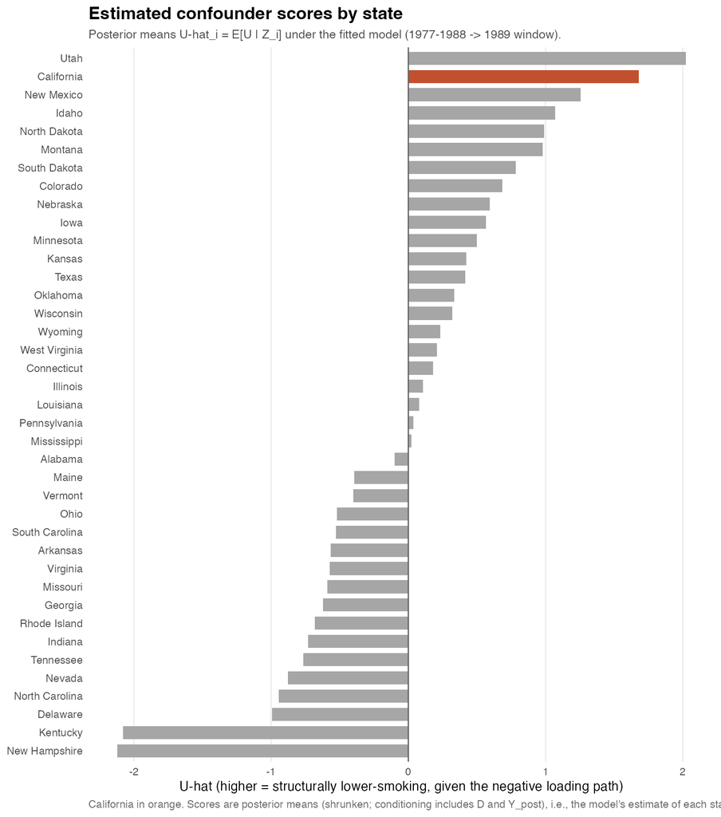

**Mean-balancing on $Y_{pre}$ does not balance the fitted $\hat U$.** California scores $1.68$; the balanced donors reach only $0.57$.

- The weights *do* go mostly to high-$\hat U$ states: New Mexico 23%, Utah 15%, Montana 14% — 7 of 38 donors carry 80% of the weight (effective $n \approx 8$).
- But they also mix in **low-$\hat U$** states, North Carolina 9% and Nevada 5%, to match features of the pre-path, hence residual imbalance on fitted $\hat{U}$. Characterizes EIV risk.

## Sensitivity results

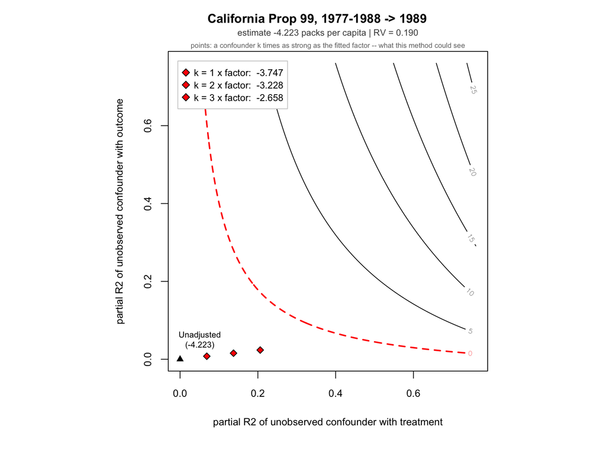

How strong would a *further* confounder have to be to overturn this?

|  | $\hat\tau$ | RV | $k=1$ | $k=2$ | $k=3$ |
| --- | --- | --- | --- | --- | --- |
| **1989** | $-4.22$ | $0.190$ | $-3.75$ | $-3.23$ | $-2.66$ |
| 1990 | $-3.97$ | $0.083$ | $-1.63$ | $+0.84$ | $+3.44$ |

$k$ = a further confounder $k$ times as strongly related to $D$ and $Y_{\text{post}}$ as the factor we already removed.

- The usual caveat: a benchmark is not a robustness test. Worse, we don’t know how well the estimated $f_t u_i$ captured confounding.
- Not as convincing as settings where we know a particular $X$ was central to selection or the outcome…(in fact maybe we should include $X$ in the full model and use those!)
- We can benchmark against $Y_{pre}$ as well…perhaps impractically high, but convincing if confounding that large wouldn’t matter.

## Conclusions thus far

1. **Prior outcomes don’t automatically buy you identification.** Different methods take different bets about structure and confounding, and no method covers some very plausible cases.
2. **The failures sort into two families.** Differencing breaks under feedback, with no confounder needed at all, and autocausation doesn’t help. Conditioning survives both of those but handles even time-invariant confounding poorly due to errors-in-variables.
3. The **synthconf** approach essentially builds on LDV but additionally models a synthetic confounder, with identification driven by imposing a vanishing lag assumption. An OVB sensitivity analysis is natural to show how residual confounding would alter conclusions.
4. Practical upshots, at the moment:
- FE+LDV has its place; it shouldn’t be illegal.
- While LDV and others in the conditioning family pay an EIV cost that is very apparent in simulations, in practice the results differ little from synthconf (so far).
- Still, synthconf may be promising as “LDV plus rank-1 confounding catcher”, the variance premium is not very large, and the estimated $U$ and $f$ may be informative.

# Backup

## Agreement is not vindication unless you know why

And *which* method is the outlier is **horizon-dependent**. Two years out TWFE falls to $+0.088$, near the conditioning family, while DiD ($-0.031$) and TWFE + lagged DV ($+0.009$) become the low outliers. Majority vote would have given you a different answer at each horizon.

3. **A price for what is left over.** Robustness values of $0.05$ (one year) and $0.11$ (two years), and an if–then against a named yardstick — not a clean bill of health.

Without the model you have three numbers agreeing, one disagreeing, and no principled way to choose between them.

## Why a 0.71 confounder moved the answer by 0.03

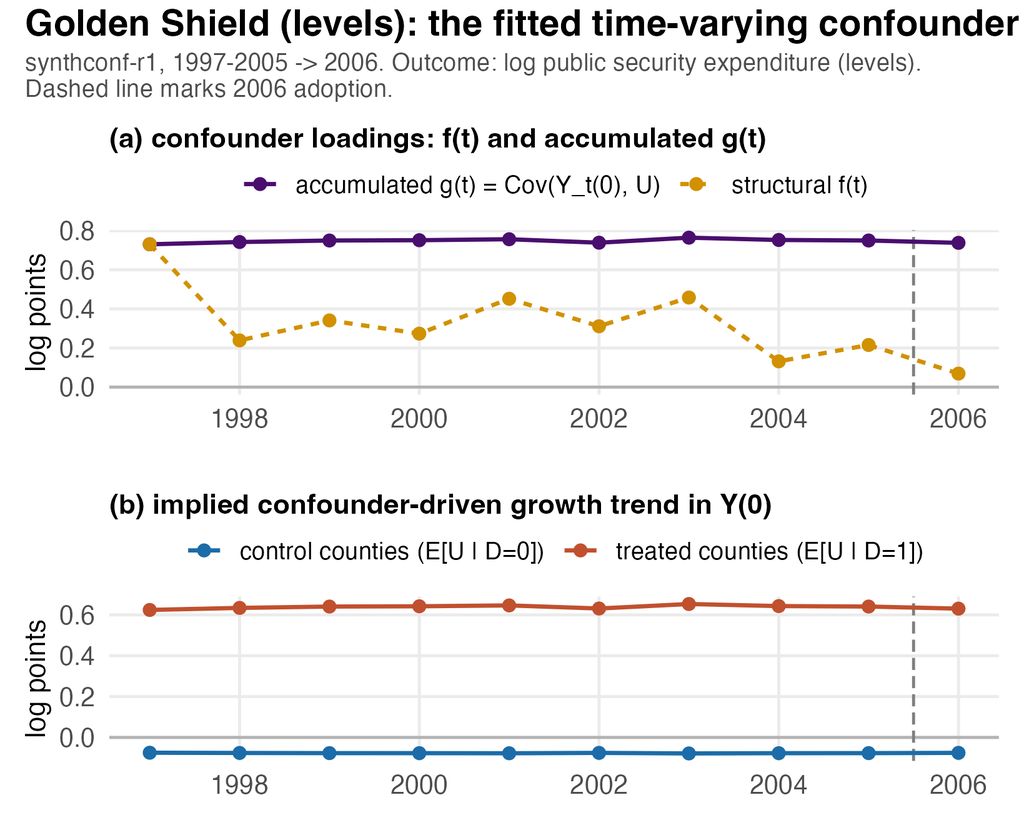

## What $Y_{pre}$ could and could not reach

- The observed $0.856$ gap decomposes into **0.706 confounder + 0.120 dynamics + 0.030 effect** — summing to $0.856$.
- Almost none of what $Y_{pre}$ reaches is reached *nonlinearly*: the nonlinear-only share of the gap is about **2%**. So kernel and trajectory balancing buy very little here — pointed, because the published analysis leans on trajectory balancing.
- And the bridge is excellent **in both senses**: the $R^2$ of $U$ on $Y_{pre}$ is **0.968** on average, *and* in the selection-relevant direction — the part of the $U$ gap $Y_{pre}$ cannot see is essentially zero.

  **That is why conditioning works here — and it is the reason to believe the agreement, not merely to observe it.**

A bridge good on average *can* still fail in the direction that matters — partial $R^2$ is scale-free, so the two are not the same question. Golden Shield simply is not an example of it.

## Golden Shield: the estimates

| method | assumption | 2006 (impact) | 2007 (cumulative) |
| --- | --- | --- | --- |
| DiD (last pre-period) | parallel trends | +0.004 | -0.031 |
| **Two-way FE (TWFE)** | constant unit effect | +0.123 | +0.088 |
| TWFE + lagged DV | unit effect + lag | +0.041 | +0.009 |
| LDV | $Y_{pre}$ sufficient | +0.031 | +0.081 |
| balance on $Y_{pre}$ / synth | $Y_{pre}$ sufficient | +0.023 | +0.053 |
| synthconf-rp | rank one (preferred) | +0.031 | +0.084 |
| **synthconf-r1** | rank one (imposed) | **+0.030** [+0.003, +0.061] | **+0.083** [+0.048, +0.119] |

Published (Xu 2021): TWFE **+0.116**, lagged DV **+0.036**, trajectory balancing **+6.9%**, reported as “4–12%”. Our one-year estimate sits at the **bottom edge** of that range; the two-year, cumulative one sits **inside** it.

## B1. Full ablation grid, $n = 2000$

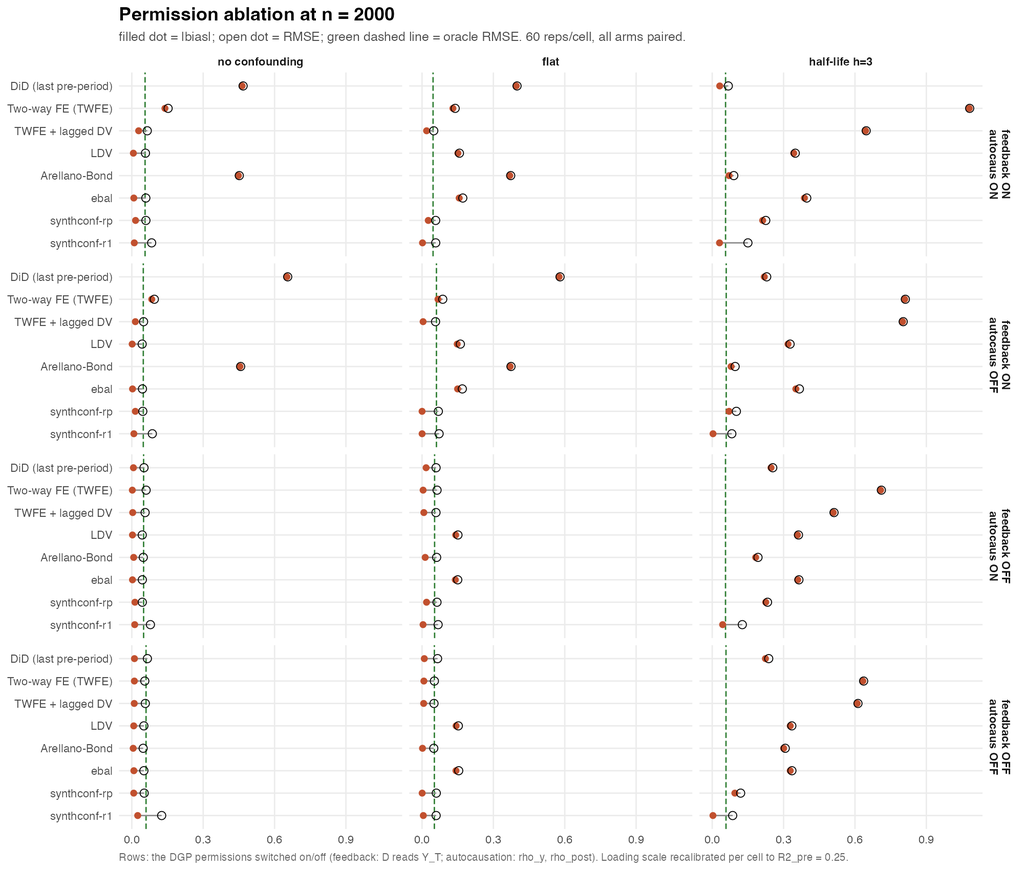

## B2. Heat map, $n = 2000$

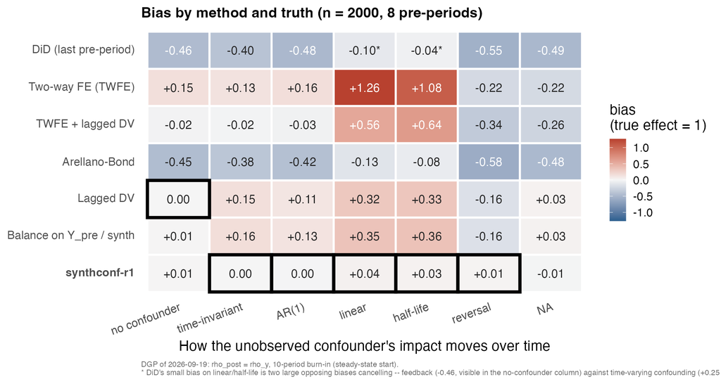

## B3. Debiasing in three acts

- Projected-gradient refit stalls (answer depends on the iteration cap).
- Exact refit exposes a ridge at the null: the (Y_T, D, post) triangle.
- Fixed tie-break penalty poisons large n; a rank gate is underpowered; a fixed-strength prior c/n works with no gate.

## B4. Dead ends

- Rank-one completion on the inverse sample covariance: needs the inverse.
- Convex smoothness penalty: flexibility pays, the prior does not.

## B5. Coverage

- SE calibrated everywhere; raw coverage 87.5-89% on hard truths at moderate n is bias, not width (debiased coverage 93-94.5%); tail effect 90-93% at large n.

## B6. Sensitivity-analysis truth-recovery test (planned)

## B7. Panel length

- EIV retires in T, shape-dependently; synthconf-rp error retires in n at fixed T.

## B9. California: anticipation

- 1988 is post-passage; ending pre in 1987 makes every estimate ~40% larger and pushes CA outside the hull.

## B10. California: weights vs scores

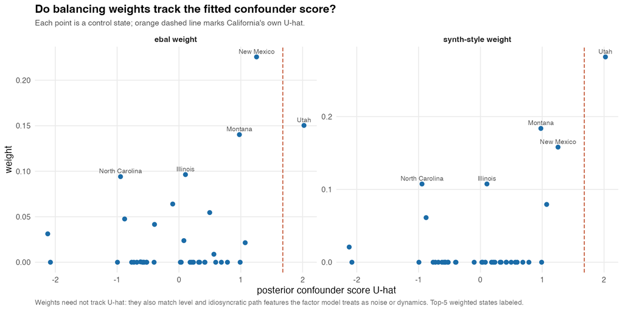

## B11. Golden Shield: scores

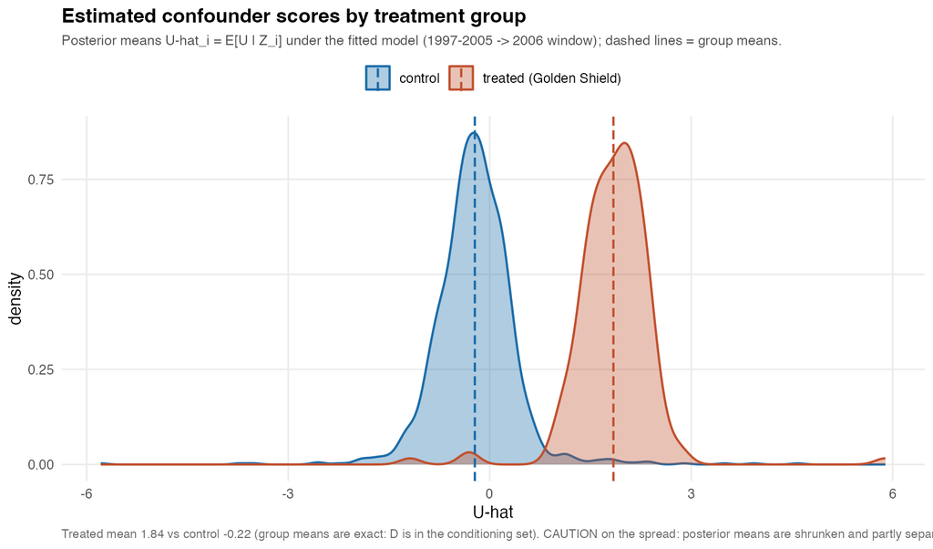

## B12. Golden Shield: window sensitivity

**This is the DIFFERENCED specification — the cautionary one (B22), not the levels fit the talk reports.**

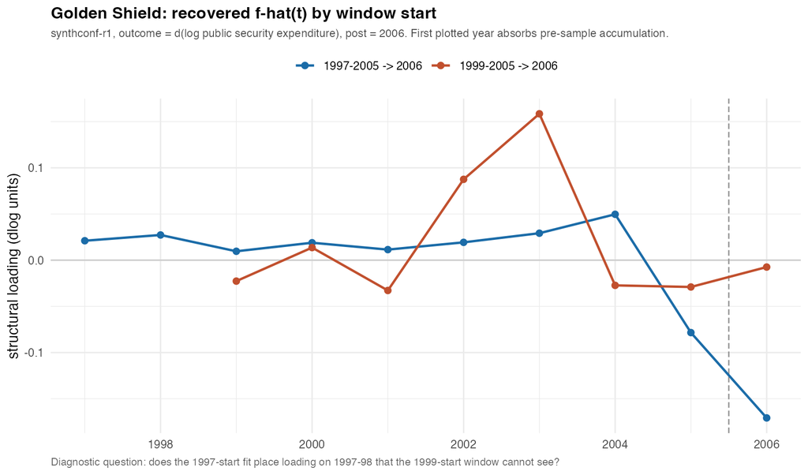

- It shows the *mechanism* behind B22’s “wild window sensitivity”: the 1997-start fit places loading on 1997–98 that a 1999-start window cannot see, so 1997-start finds a coherent hot-then-dip factor while 1999-start finds noise and no dip loading.
- In **differences** that swing is ten- to thirty-fold ($+0.357$ from 1997 against $+0.01$–$+0.03$ from 1999). In **levels** the same comparison is stable: $0.0298$ against $0.0288$.

## B13. No sleeping giants, formally

## B14. Dominance in two layers

## B15. GP-LDV

## B16. Why the shape rungs were retired

## B17. A pre-treatment surge that is not anticipation (reversal)

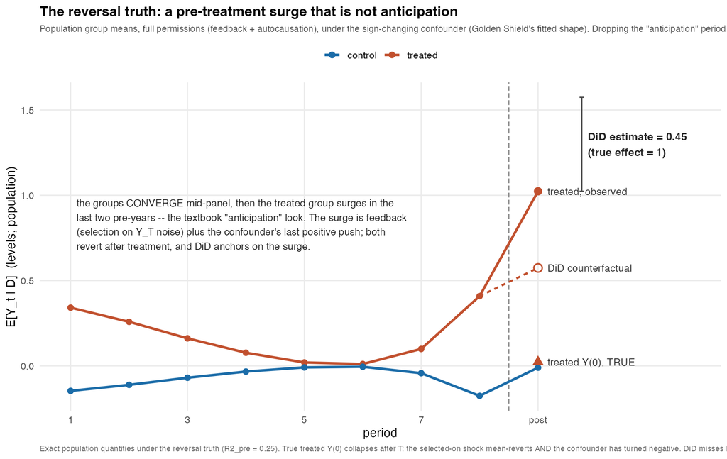

## B18. Where DiD gets lucky: a tale of two biases

- **Confounding.** The treated differ in $U$, and a *moving* impact shifts their untreated outcome between $T$ and post by a different amount than the controls’. Exactly: $[\,f_{\text{post}} - (1-\gamma_{\text{post}})\,g_T\,]\;\Delta_U$; zero for a flat $f$ at steady state, positive when the impact is still rising.
- **Feedback.** Selection on $Y_T$ picks units with a high shock; only a fraction $\gamma_{\text{post}}$ of it carries into $Y_{\text{post}}$, but DiD subtracts *all* of $Y_T$. Exactly: $-(1-\gamma_{\text{post}}) \times$ (noise gap in $Y_T$); negative whenever selection is on a high shock, no confounder needed. DiD is LDV with the coefficient on $Y_T$ fixed at 1.

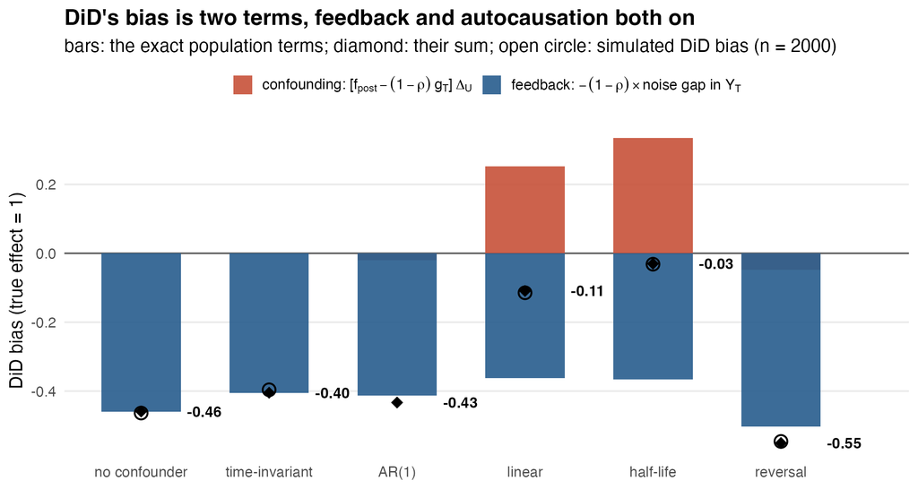

## B18b. DiD’s zero is a crossing

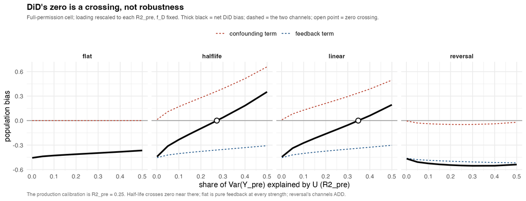

## B19. The insurance premium (bias assumed away is variance not paid)

| truth | $n$ | DiD | FE | LDV | synthconf-rp | synthconf-r1 |
| --- | --- | --- | --- | --- | --- | --- |
| none | 2000 | 1.09 | 0.91 | 0.85 | 0.87 | 2.10 |
| flat | 2000 | 1.26 | 1.00 | 2.94 | 1.16 | 1.14 |

RMSE relative to the oracle, both permissions off.

## B20. (Old route) The world, stacked

Recall the world, one unit at a time:
$$Y_{it} = \textstyle\sum_{t-s\le\nu}\gamma_{s,t}Y_{is} + f_t U_i + \varepsilon_{it},\qquad
D_i = \mathbf{1}\{\textstyle\sum\gamma_{s,D}Y_{is} + f_D U_i + \varepsilon_{iD} > c\},\qquad
Y_{i,\text{post}} = \textstyle\sum\gamma_{s,\text{post}}Y_{is} + \tau D_i + f_{\text{post}}U_i + \varepsilon_{i,\text{post}}$$

- Stack one unit’s observables: $Z_i = (Y_{i1},\ldots,Y_{iT},\ D_i,\ Y_{i,\text{post}})^\top$. Direct effects in $\Gamma$ (strictly upper triangular; **$\tau$ is an entry**). The confounder’s impacts on each coordinate stacked into one vector, $f = (f_1,\ldots,f_T,\ f_D,\ f_{\text{post}})^\top$.
- Then the three equations are one line: $\ Z_i = \Gamma^\top Z_i + f\,U_i + \varepsilon_i$, i.e. $\ (I-\Gamma^\top)\,Z_i = f\,U_i + \varepsilon_i$.
- Let $\Sigma_{\text{obs}} = \operatorname{Var}(Z_i)$: the covariance of everything we observe, confounding included. Solving the system, $Z_i = A^{-1}(f\,U_i + \varepsilon_i)$ with $A := I-\Gamma^\top$, so
  $$\Sigma_{\text{obs}} = A^{-1}\big(ff^\top + \Sigma_\varepsilon\big)A^{-\top}\quad\Longleftrightarrow\quad A\,\Sigma\,A^\top = ff^\top + \Sigma_\varepsilon .$$
  Here $\Sigma_\varepsilon = \operatorname{Var}(\varepsilon_i) = \operatorname{diag}(\sigma^2_{\varepsilon,1},\ldots)$ is **diagonal** (disturbances independent across coordinates). Undo the dynamics and what is left is a rank-one piece (the confounder) plus a diagonal one (the noise), and those two can be told apart.

## B20b. (Old route) The part of $Z$ due to $U$, and the rest

- Solving the system splits every unit’s data into two independent pieces:
  $$Z_i = \underbrace{A^{-1}f\,U_i}_{\text{due to } U} \;+\; \underbrace{A^{-1}\varepsilon_i}_{\text{the rest}} .$$
- Independent pieces have covariances that add:
  $$\Sigma_{\text{obs}} \;=\; \underbrace{\Sigma_U\Sigma_U^\top}_{\text{rank one}} \;+\; \underbrace{\Omega}_{\text{deconfounded}},\qquad \Sigma_U = A^{-1}f = \operatorname{Cov}(Z_i, U_i),\quad \Omega = A^{-1}\Sigma_\varepsilon A^{-\top}.$$
  $\Omega$ is the covariance of the data *with the confounder’s contribution removed*.
- Why $\Omega$ is the object we want: a regression that controls for $U$ has the same coefficients as the same regression run on the “rest” pieces alone (partialling out $U$ leaves exactly $A^{-1}\varepsilon_i$). And regression coefficients are ratios of precision-matrix entries. So **$\tau$ lives in $\Omega^{-1}$.**
- Write $S := \Omega^{-1}$, the *deconfounded precision*. If we could see $U$ (the oracle row on the map), we would have $S$ directly, and
  $$\tau = -\,S[D,\text{post}]\,/\,S[\text{post},\text{post}].$$

## B20c. (Old route) Marginalising $U$ costs exactly a rank-one term

- The observed precision is $\Sigma_{\text{obs}}^{-1} = S - L$, with $L$ **rank one** (Schur complement of the $(Z,U)$ precision; one $U$, one rank).
- Reading the same ratio off $\Sigma_{\text{obs}}^{-1}$ instead of $S$ is **LDV**; its bias is whatever $L$ contributes to the $(D,\text{post})$ corner.
- So the problem is: recover $S$ from $\hat\Sigma_{\text{obs}}^{-1}$, knowing only that what is missing is rank one.

## B20d. (Old route) Vanishing lag is a known zero pattern in $S$

[figure not shown]

## B21. Identifiability counting

**Constraints: number of forced zeros in $\tilde{P}$** (pairs with no direct effect and no shared child; $T$ pre-periods plus $D$ and $Y_{\text{post}}$)

|  | $T=3$ | $T=4$ | $T=5$ | $T=6$ | $T=8$ | $T=12$ |
| --- | --- | --- | --- | --- | --- | --- |
| $\nu = 1$ | 5 | 9 | 14 | 20 | 35 | 77 |
| $\nu = 2$ | 2 | 5 | 9 | 14 | 27 | 65 |

**Parameters: free entries of a rank-$r$ PSD $L$**, $r(T+2) - r(r-1)/2$

|  | $T=3$ | $T=4$ | $T=5$ | $T=6$ | $T=8$ | $T=12$ |
| --- | --- | --- | --- | --- | --- | --- |
| rank 1 | 5 | 6 | 7 | 8 | 10 | 14 |
| rank 2 | 9 | 11 | 13 | 15 | 19 | 27 |
| rank 3 | 12 | 15 | 18 | 21 | 27 | 39 |

## B22. The differenced Golden Shield run (cautionary)

- Running the same data in **first differences** gave $+0.357$, twelve times the levels estimate, with wild window sensitivity and the two synthconf versions disagreeing fivefold.
- Why it was wrong: differencing an AR(1) produces an **MA(1) error structure** and so a **dense** precision matrix, so the estimator’s zero pattern no longer holds. The raw lag-1 correlation of the differenced series is $-0.224$, essentially the $-0.201$ an AR(0.60) in levels implies — an over-differencing signature, not “mean reversion in growth rates.”
- Kept as an illustration of what a violated dynamics assumption does to an estimate. The mechanism behind the window sensitivity is B12.

## B23. Shortening the panel on Golden Shield (a clean negative)

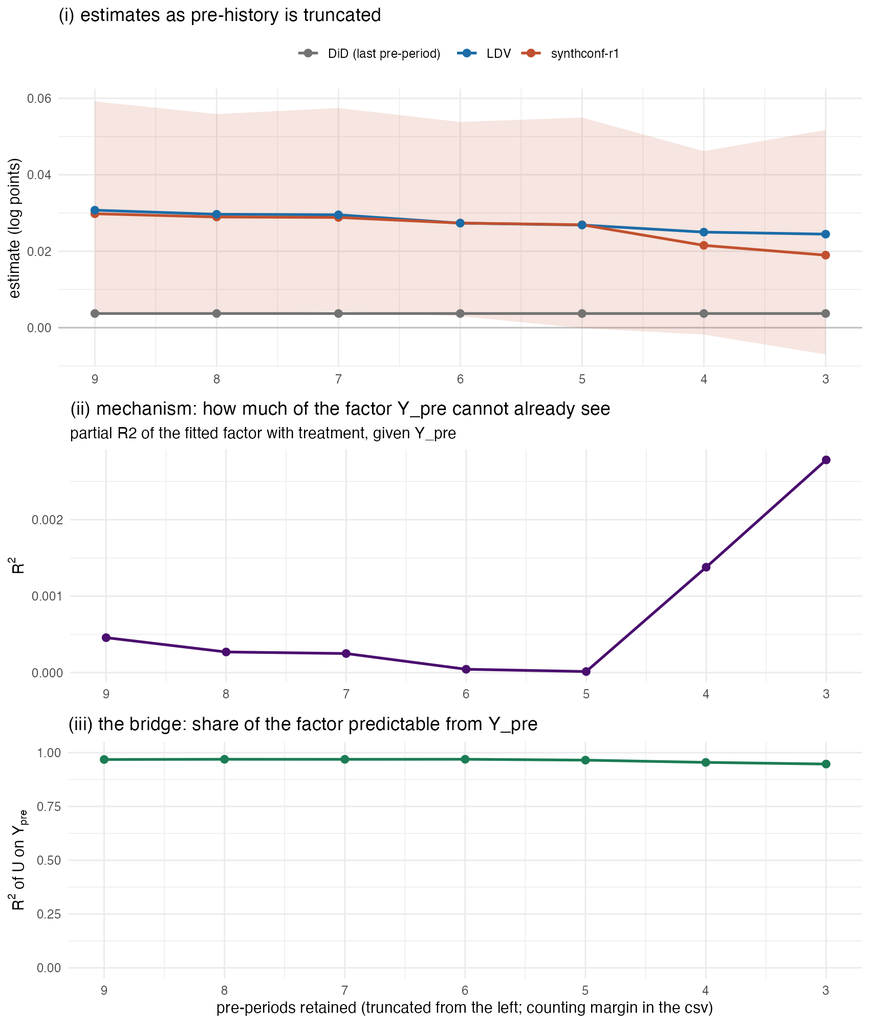

## B24. Below the counting floor, nothing breaks

- $T = 3$ is **exactly** identified (counting margin $0$), not the wall; the wall is $T = 2$, at margin $-2$. See the counting table.
- At $T = 2$ the fit **converges cleanly** — gradient $2\times10^{-7}$, no warning, no boundary flag — and returns a perfectly plausible $+0.0095$. *Under-identification does not announce itself.*
- What it actually is, is **regularisation-determined**. Sweeping the ridge $c$ over $0.25$–$32$:

  | counting margin | $+33$ | $+18$ | $+7$ | $+3$ | $0$ | $-2$ |
  | --- | --- | --- | --- | --- | --- | --- |
  | spread in $\hat\tau$, as a share of $\hat\tau$ | $5\%$ | $3\%$ | $3\%$ | $11\%$ | $16\%$ | $184\%$ |

- Small and flat while the margin is comfortable, rising as it closes, an order of magnitude larger below the floor. $\mu$ is *not* the knob — $\hat\tau$ is $\mu$-invariant even at margin $-2$.
- **What we did about it (2026-09-22):** the estimator now **refuses**. `sparse_lowrank_cvx` counts the margin before fitting — negative stops with the margin and the constraint/parameter counts; zero warns that nothing over-identifying remains. A converged, ridge-determined number is a worse outcome than an error.
- Where the check cannot be had, the ridge sweep is the diagnostic: large relative movement of $\hat\tau$ across $c$ is what under-identification looks like when nothing else announces it.

## B25. Nickell bias, exactly

Nickell, S. (1981), “Biases in Dynamic Models with Fixed Effects,” *Econometrica* 49(6), 1417–1426.

**The model.** A unit effect and one lag: $\;Y_{it} = \alpha_i + \gamma\,Y_{i,t-1} + \varepsilon_{it}$, where $\varepsilon_{it}$ is the shock to $Y_{it}$.

**In levels there is no problem.** $Y_{i,t-1}$ is realised *before* $\varepsilon_{it}$, so they are uncorrelated. If we could see $\alpha_i$ and subtract it, OLS would be fine.

**The within transform is *demeaning*, not differencing.** It replaces both sides by deviations from the unit’s own average over the estimation window:

$$\underbrace{Y_{it} - \bar{Y}_i}_{\text{outcome}} \;=\; \gamma\,\underbrace{\big(Y_{i,t-1} - \bar{Y}_{i,-1}\big)}_{\text{regressor}} \;+\; \underbrace{\big(\varepsilon_{it} - \bar{\varepsilon}_i\big)}_{\text{error}}$$

**Where the correlation comes from.** $\bar{Y}_{i,-1}$ averages $Y_{i,0},\ldots,Y_{i,T-1}$ — and that average includes $Y_{it}, Y_{i,t+1},\ldots$, every one of which is a *descendant* of $\varepsilon_{it}$. So the regressor now depends on $\varepsilon_{it}$, with weight $1/T$ and a **negative** sign (it is subtracted).

> Demeaning contaminates a strictly-past regressor with the future.

**Why demeaning alone is not the culprit.** Demeaning contaminates *everything* with every shock — but bias needs the **regressor** correlated with the **error**. For a strictly exogenous $X$, the demeaned regressor is a function of $X$ alone and the demeaned error a function of $\varepsilon$ alone: uncorrelated, and FE is unbiased even at $T=4$.

**A lagged outcome is different.** $Y_{i,t-1}$ *is* a function of past shocks, and demeaning drags past shocks into the error. So the condition FE needs is **strict exogeneity**, not merely predeterminedness — and a lagged outcome is predetermined but never strictly exogenous.

## B25b. Nickell bias, measured

**Measured** ($\gamma = 0.5$, $N = 20{,}000$, `tools/nickell_demo.R`):

| $T$ | 4 | 8 | 16 | 32 |
| --- | --- | --- | --- | --- |
| $\operatorname{cor}(Y_{t-1},\ \varepsilon_t)$, levels | $+0.007$ | $+0.004$ | $+0.001$ | $+0.002$ |
| $\operatorname{cor}(Y_{t-1}-\bar{Y},\ \varepsilon_t)$, within | $-0.386$ | $-0.221$ | $-0.112$ | $-0.055$ |
| bias in $\hat\gamma$ | $-0.54$ | $-0.24$ | $-0.11$ | $-0.05$ |

Both halve with each doubling of $T$: the $O(1/T)$ signature. Note it is $O(1/T)$, **not** $O(1/n)$ — more units do not help.

**Two things this rules out.** It is *not* about the post-period — there is no treatment anywhere in that simulation. And you cannot drop your way out: removing the last period from the mean leaves the bias at $-0.201$ against $-0.204$. Whichever way the mean looks, it collides with the lag, which is why the literature goes to first-differencing plus instruments (Arellano–Bond) rather than to dropping a period.

**And it can still be worth paying.** On a time-invariant confounder this arm sits at the oracle RMSE floor while LDV pays errors-in-variables. A known bias is not a reason to discard an estimator; it is a quantity to put on the scale.